# UPSIDE EDUCATION

1.Question/Problem

2.Introduction

3.Survey

4.Analysis&Insights

5.Proposed_Solution

## 1.Question/Problem

- How can we bridge the gap between the students and teachers?
- Providing an excellent learning experience?
- Ensuring full coverage and proficiency in any of the subjects or field being learnt?

## 2. Introduction

> > My main aim for this presentation is to breach the gap in the educational sector between the Students and the Teachers at the same time ensuring that every student gets a wonderful thorough learning experince and knowleged in whatever field or subject they choose to venture in .

> Imagine a class of 52 and a class of 200 being taught the same subject by one teacher , which of these classes will probably have a higher success rate in the subject being taught and which of these classes would have had a more closer supervision through out their period of learning ?

> The class of 52 would come out true on both instances above. But what if that wasn't the case and both classes came out true in both cases ,tell me wouldn't that be great ? The fear a student has thinking he isn't going to enjoy the class due to the fact that they might be so many students in the class can now be a thing of the past .

> Through **DATA SCIENCE** which helps in making the learner feel special in conjuction with an **ALLURING UI** which will help in captivating and motivating the learner. The above instance willbe a thing of the past .

## 3. Survey

> A survey was taking using google forms to see what type of learning technique people prefer . I had a total of 33 responses from the survey and which I later analyzed for futher insights .

> During my research on learning techniques , I came across a similar survey carried out to find out **what best strategies of teaching will be provided for better interaction and better learning process**.Similar to this survey I carried out this survey to find out how to improve learning experience since everyone doesn't learn the same way

### A display of the questions asked in the survey :

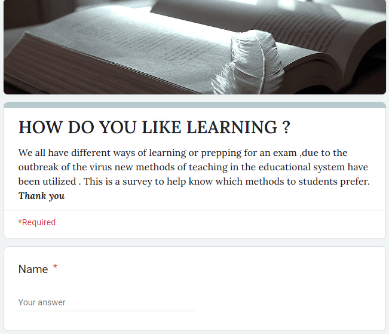

[figure not shown]

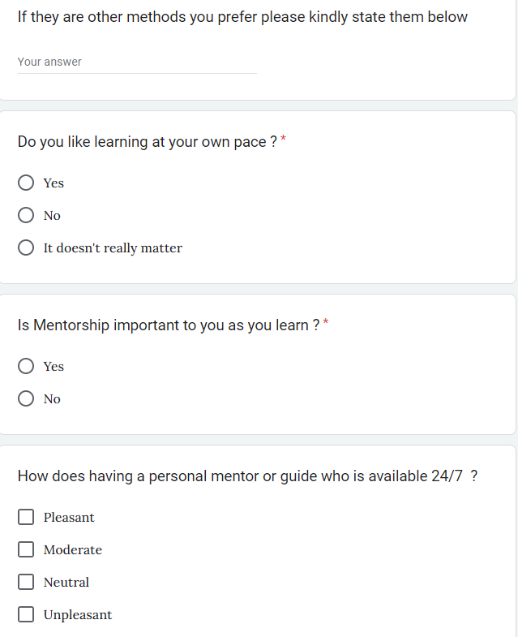

### The gathered dataset:

##### Through this data you will notice that people prefer different ways of learning and opinions on the presence of a mentor/guide during the learning process.

|  | Name | Education_LVL | Learning_Practice | Pace_Learning | Mentorship_Importance | Mentorship_Guide |
| --- | --- | --- | --- | --- | --- | --- |
| 0 | Gerald | University | Project-Based | Yes | Yes | Moderate |
| 1 | Ugochi | University | Blended | Yes | Yes | Pleasant |
| 2 | Abraham | High_school | Blended | Yes | Yes | Pleasant |
| 3 | Ugbo | University | Online | Yes | Yes | Neutral |
| 4 | Aderinsola | University | Blended | Yes | No | Neutral |
| 5 | Akuoma | University | Project-Based | Doesn't_matter | Yes | Moderate |
| 6 | Ebube | High_school | Physical | Yes | No | Unpleasant |
| 7 | Janefrances | University | Blended | Yes | No | Neutral |
| 8 | Gabriella | High_school | Project-Based | Doesn't_matter | Yes | Pleasant |
| 9 | Okoli | University | Blended | Yes | Yes | Neutral |
| 10 | Kamso | University | Project-Based | Yes | Yes | Pleasant |
| 11 | Esther | University | Blended | Yes | Yes | Moderate |
| 12 | Folorunso | University | Blended | Doesn't_matter | Yes | Pleasant |
| 13 | Chidinma | University | Physical | Yes | No | Moderate |
| 14 | Somorin | University | Blended | Doesn't_matter | Yes | Pleasant |
| 15 | Amarachi | Masters | Blended | Yes | Yes | Pleasant |
| 16 | Ebuka | University | Blended | Yes | Yes | Pleasant |
| 17 | Vee | University | Project-Based | Yes | Yes | Pleasant |
| 18 | Jite | High_school | Project-Based | Yes | No | Pleasant |
| 19 | Oladipo | University | Personal | Yes | Yes | Pleasant |
| 20 | Divine | University | Blended | Yes | Yes | Pleasant |
| 21 | Abbey | Masters | Blended | Yes | Yes | Moderate |
| 22 | Moyo | University | Personal | Yes | Yes | Neutral |
| 23 | Victor | University | Online | Yes | Yes | Moderate |
| 24 | Azeez | University | Project-Based | Yes | Yes | Pleasant |
| 25 | Babatunde | University | Project-Based | Yes | Yes | Pleasant |
| 26 | Gariat | High_school | Home_schooling | Doesn't_matter | Yes | Neutral |
| 27 | Alokam | University | Blended | Doesn't_matter | Yes | Pleasant |
| 28 | Adeshokan | University | Online | Yes | Yes | Moderate |
| 29 | Joemike | University | Physical | Doesn't_matter | Yes | Moderate |
| 30 | Adeyemi | High_school | Physical | Yes | Yes | Pleasant |
| 31 | Halidu | University | Project-Based | Yes | Yes | Neutral |
| 32 | Giovanni | University | Blended | Doesn't_matter | Yes | Pleasant |

## 4. Analysis&Insights

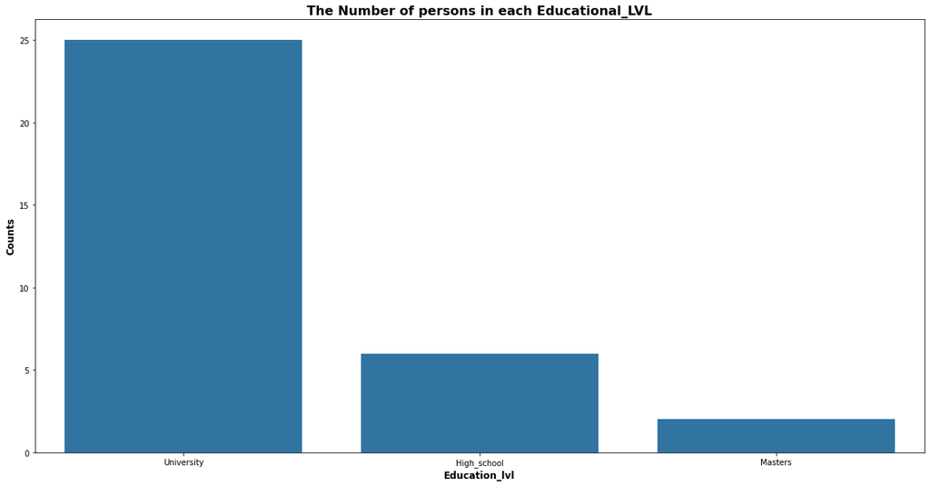

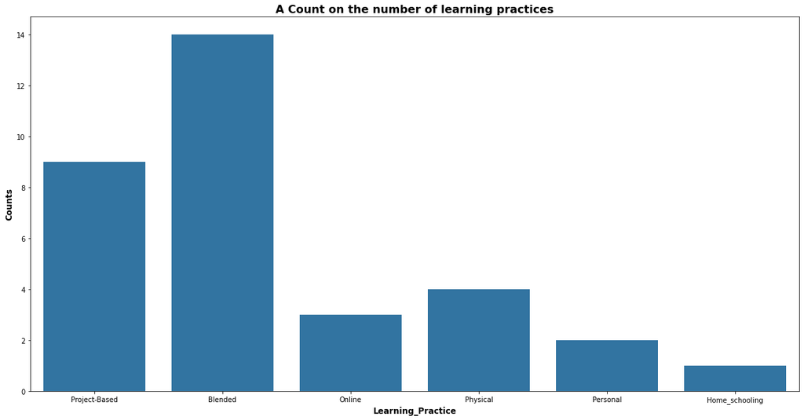

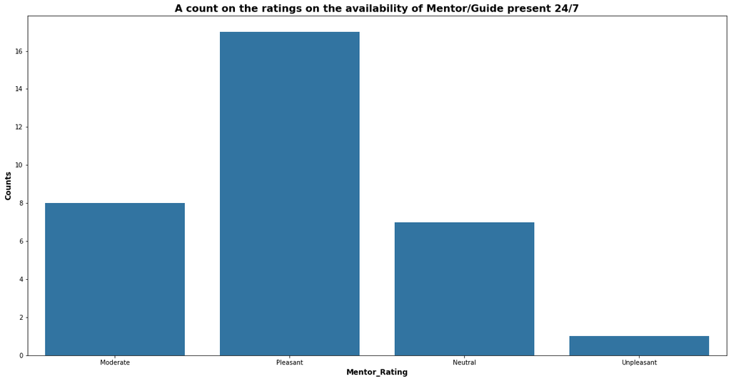

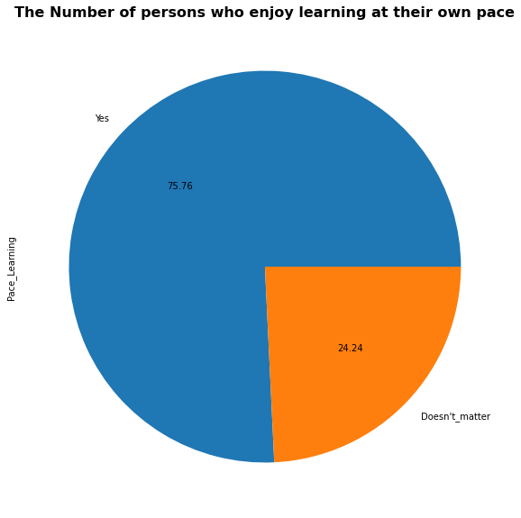

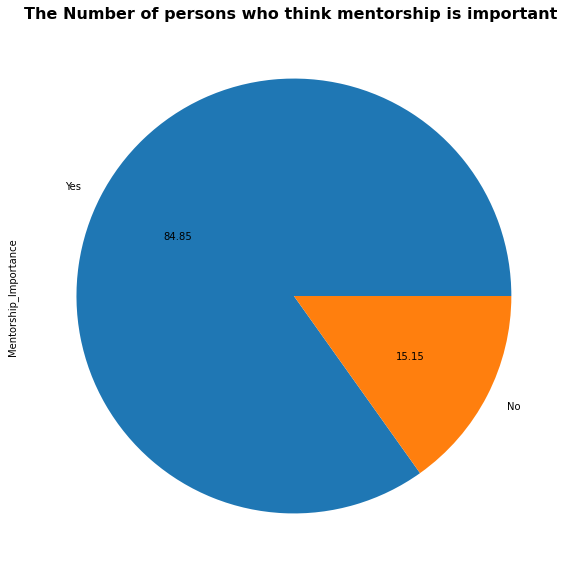

> - This survey shows that most of the inputs came from students in University level and the type of the learning technique preferred by most students is the **Blending** seconded by the **Project_Based** learning techniques.
> - Most of the student prefer learning at their own **Pace** and regard the presence of a **Mentor/Teacher** to monitor their progress and give responsive feed backs to be highly important and also find the presence of a 24/7 guide **PLeasant**.

### Futher analysis

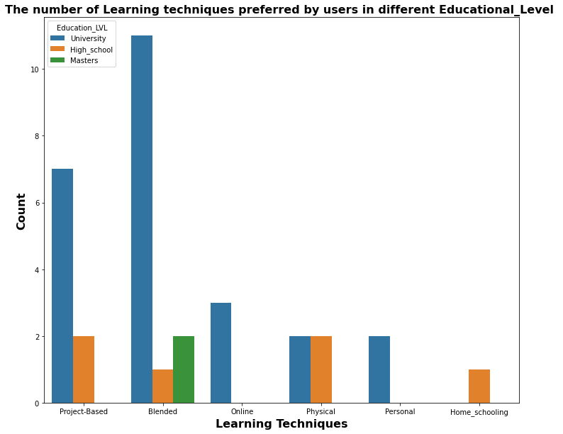

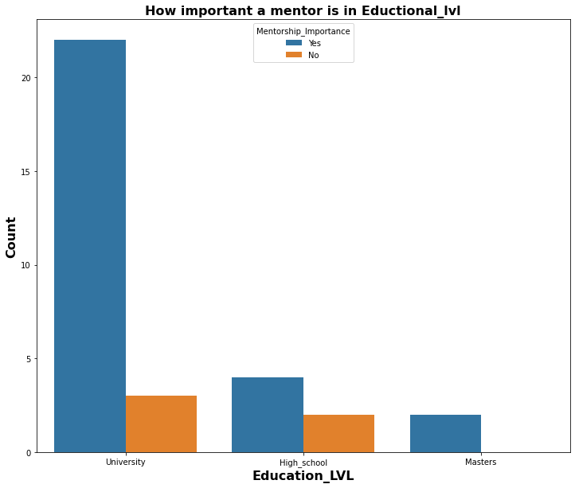

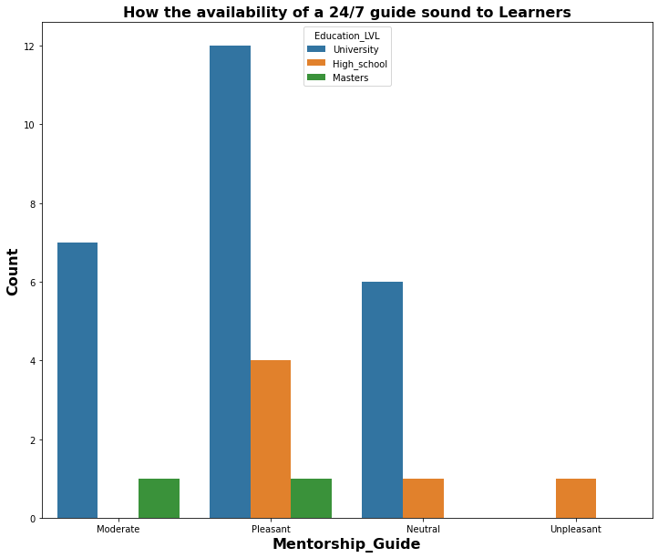

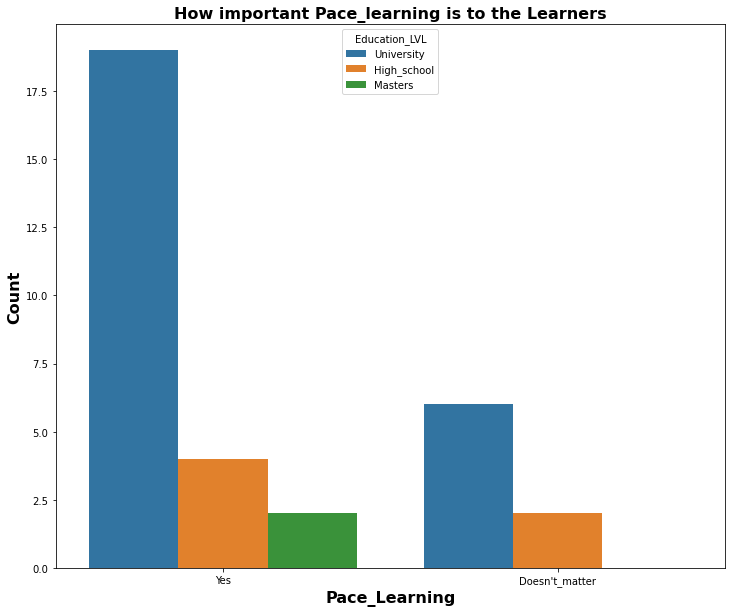

## 5. Proposed_Solution

## Summary of the Platform

I suggest building a software which will have an intregrated algorithm for the purpose of learning the users/learners skills and help improve the users knowledge and skills in the field the users chooses to learn or venture. The software will have to integrate a very attracting UI which will keep the user intrested and also help by increasing his time spent learnng .

### Increasing the time spent learning

> **The main goal of this solution is to create a platform that is best set to each individual learning preference in hopes of giving the best User experience and achieving ones goals.**

> I propose a platform which could help increase the learners devotion to learning by integrating a UI that can captivate the learners mind and also integrate a very interactive simulation just like a game but one in which the learner will not find learning tedious. Such integrations could be:
- *Availaibility of different learning themes:*

> > Learning in an enviroment that has maybe one of your favourite movies as the theme setting ,would be very intresting and make the learning process seem fun. For example , I love the movie Harry potter and there's a theme like that and I choose that as my new theme.Everytime I open the learning platform ,it displays something like this;

[figure not shown]

## *Integrating an algorithm that grows with the user/learner:*

> Spotify is highly recommended and has been said to be the best music listening platform, this is because of the amazing algorithm integrated in the app which studies the type of music the user listens to and also recieves data on the type of sound and musicians the user enjoys listening to .

> > The more data we have about our user the more we can make the user feel comfortable and intrested while learning . Using data science to create an algorithm that will be trained to activate different teaching techiques based on the data the user feeds the data.

> Data will be gotten from the user by asking questions during the registration or the signing up stage such as :
> - Name ?
> - Age ?
> - Current Educational_level ?
> - Type of learning techniques preferred by you ?
> - Program to be studied ?
> - Why are you studying this program (Exam/Job/General knowledge)?
> - Future Occupation? Through the continuous gathering of this data and proper monitoring of the learners pattern when learning , in the future the algorithm will be able to predict the maximum amount of time needed to be put in to guarantee an excellent result in whatever field or skill being learnt .

### Motivating the learners

> The platform will have a system that helps motivate the learners by bringing up wonderful facts about their role models or from their respective intrested fields , for eample ;
> - **Lets help you be as succesful as Denzel Washighton**

>   ```
>                    OR
>   ```

> - **Through constant practicing and hardwork on balancing acoounting sheets you could be the head of an accounting team at a very young age in a multi international company** e.t.c . By asking the user to write a list of his role models when signing up .
> - Role models?

## The Perfect Teachers Assistant:

> With the implementation of this algorithm , the workload on the the teacher is greatly reduced and the student have a 24/7 guide who sole priority isto ensure the progres of the student.

> By studying the progress of a student through their test scores in every checkpoint or each section of the subject or field being learnt , the platform will tell the student ,in what part he needs to revisit to attain mastery or in ensuring a good grade .The platform will also help in referring extra videos or writings in the that particular field.

> The platform will help in giving the teacher feed back on the time spent by the student each day and how many attempts the students had before answering a test question grading the student with each try but this inforation is only visible to the teacher, to help the teacher know when a student is stuck on a certain task or isn't progressing .This will also help the teacher in having a very direct conversation with the student and hence build a relationship between the teacher and student . A **Request Guide** option wil aslo be implented in order for the student to reach out for assistance immidiately and if response is delayed the student could pose his difficulty and the memo will be passed to every teacher teaching that field.

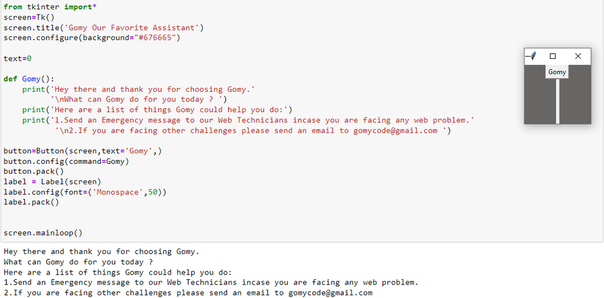

[figure not shown]